# Can we predict IMDb movie ratings?

Ana Martins, Hsuan Lee, Timo van Veghel

October/November 2022

## Goals

In this project, we aim to find out if there is a way to predict whether a movie has the potential to in the IMDB top 1000. According to the [IMDB website](https://www.imdb.com/search/title/?groups=top_1000&sort=user_rating,asc), an IMDB rating of at least 7.6 is required for a movie to be part of the top 1000. Our models will be based on a randomized dataset, retrieved from the [IMDb API](https://imdb-api.com). Hopefully our model will be sufficiently accurate to let us know which movies to visit the cinema for!

## About the Dataset

The dataset we will be using is taken from the [IMDb API](https://imdb-api.com) on the 4th of November of 2022, as we did not find any dataset online that satisfied what we wanted (they were either too big, too small, or had wrong data). The maximum amount of data we can get at once is 250 movies, so what we do to try to generate (mostly) random data is searching for movies with each of the genres available and getting them by ascending and descending alphabetical order (see data/movie_data_generating.py for more details). The starting dataset contains 9414 random (see below why we can call them random) movies that are on IMDB.

The dataset has 14 variables: `id`, `image`, `title`, `description`, `runtimeStr`, `genres`, `genresList`, `contentRating`, `imDbRating`, `imDbRatingVotes`, `metacriticRating`, `plot`, `stars` and `starList`.

We will be taking away variables that do not interest us, like `image`, `genresList` (we have the genres in `genres` already), `plot` and `starList` (again, we have the actors in `stars` already), as those are not useful to analyse. Variables like the `stars` are also not useful for direct analysis, because they would most definitely result in overfitting due to the high variability per movie (each movie has a unique set of ‘stars’ and there is quite a lot of them), but using these to get other variables will be something we do. Another particularity of the dataset is that this data was already taken only for Feature Films, for runtime longer than 60 minutes and for more IMDb votes than 25000 (what IMDb considers to make the rating official) to eliminate titles we do not want to analyse.

## Getting the Data

We start by getting our initial dataset:

```r
library(tidyverse)
library(caret) # for fitting the trees and LR with CV
library(gbm) # for boosting
library(pander) # for pander() function, make the descriptive stat have pretty output
library(psych) # for making a descriptive statistics
library(mice) # for imputing the missing data of new movies
```

```r
library(VIM) # plot the missing data
options(scipen = 999) # remove e
set.seed(2022)
```

```r
movies <- read_csv("data/movie_data.csv")
```

Let us clean this up a bit so we do not have to carry around more than we need to:

```r
movies <-
  movies %>%
  select(-image, -genreList, -plot, -starList)
```

```r
movies <-
  movies %>%
  mutate(runtime = as.numeric(gsub(' min', '', runtimeStr))) %>%
  select(-runtimeStr)
```

```r
movies <-
  movies %>%
  mutate(contentRating = as.factor(contentRating))
```

```r
movies <-
  movies %>%
  mutate(year = as.numeric(gsub('[()]', '', description))) %>%
  select(-description)
```

Actually, looking at the `stars`, we can see that the first name listed is the Director of that film, so let us take them out.

```r
movies <-
  movies %>%
  mutate(director = sub(", .*", "", movies$stars)) %>%
  mutate(stars = substring(stars, first = nchar(director) + 3)) %>%
  mutate(actors = stars)
```

Also, because of the way the data was retrieved, we have multiples in there (e.g. on movie can be on the action and drama genres and get retrieved both times), so let’s get rid of them.

```r
movies <-
  movies %>%
  filter(!duplicated(id))
```

## Creating New Useful Variables

At the moment, our dataset is mostly made up of character variables, which will not be very useful for our purposes. So, we will start by transforming the `genres` into a dummy variable each.

```r
movies <-
  movies %>%
  mutate(
    action = ifelse(grepl("Action", genres, fixed = TRUE), 1, 0),
    adventure = ifelse(grepl("Adventure", genres, fixed = TRUE), 1, 0),
    animation = ifelse(grepl("Animation", genres, fixed = TRUE), 1, 0),
    biography = ifelse(grepl("Biography", genres, fixed = TRUE), 1, 0),
    comedy = ifelse(grepl("Comedy", genres, fixed = TRUE), 1, 0),
    crime = ifelse(grepl("Crime", genres, fixed = TRUE), 1, 0),
    documentary = ifelse(grepl("Documentary", genres, fixed = TRUE), 1, 0),
    drama = ifelse(grepl("Drama", genres, fixed = TRUE), 1, 0),
    family = ifelse(grepl("Family", genres, fixed = TRUE), 1, 0),
    fantasy = ifelse(grepl("Fantasy", genres, fixed = TRUE), 1, 0),
    filmnoir = ifelse(grepl("Film-Noir", genres, fixed = TRUE), 1, 0),
    gameshow = ifelse(grepl("Game-Show", genres, fixed = TRUE), 1, 0),
    history = ifelse(grepl("History", genres, fixed = TRUE), 1, 0),
    horror = ifelse(grepl("Horror", genres, fixed = TRUE), 1, 0),
    music = ifelse(grepl("Music", genres, fixed = TRUE), 1, 0),
    musical = ifelse(grepl("Musical", genres, fixed = TRUE), 1, 0),
    mystery = ifelse(grepl("Mystery", genres, fixed = TRUE), 1, 0),
    news = ifelse(grepl("News", genres, fixed = TRUE), 1, 0),
    realitytv = ifelse(grepl("Reality-TV", genres, fixed = TRUE), 1, 0),
    romance = ifelse(grepl("Romance", genres, fixed = TRUE), 1, 0),
    scifi = ifelse(grepl("Sci-Fi", genres, fixed = TRUE), 1, 0),
    sport = ifelse(grepl("Sport", genres, fixed = TRUE), 1, 0),
    talkshow = ifelse(grepl("Talk-Show", genres, fixed = TRUE), 1, 0),
    thriller = ifelse(grepl("Thriller", genres, fixed = TRUE), 1, 0),
    war = ifelse(grepl("War", genres, fixed = TRUE), 1, 0),
    western = ifelse(grepl("Western", genres, fixed = TRUE), 1, 0),
  ) %>%
  select(-genres)
```

These are all of the Genres available in the IMDb API. However, when retrieving the data from the API, we couldn’t find certain genres within our criteria (runtime > 60 and number of votes > 25000), so we can take those out to not carry variables we don’t need.

```r
movies <- movies[, colSums(movies != 0, na.rm = TRUE) > 0]
```

Additionally, we filter out missing values for content ratings and create dummy variables for content ratings.

```r
movies <- movies %>%
  filter(contentRating != c("Not Rated", "Unrated")) %>%
  mutate(
    PG13 = ifelse(contentRating == "PG-13", 1, 0),
    R = ifelse(contentRating == "R", 1, 0),
    PG = ifelse(contentRating == "PG", 1, 0),
    Passed = ifelse(contentRating == "Passed", 1, 0),
    G = ifelse(contentRating == "G", 1, 0),
    TVMA = ifelse(contentRating == "TV-MA", 1, 0),
    TV14 = ifelse(contentRating == "TV-14", 1, 0),
    Approved = ifelse(contentRating == "Approved", 1, 0),
    TVPG = ifelse(contentRating == "TV-PG", 1, 0),
    GP = ifelse(contentRating == "GP", 1, 0),
    NC17 = ifelse(contentRating == "NC-17", 1, 0),
    twelve = ifelse(contentRating == "12", 1, 0),
    M_PG = ifelse(contentRating == "M/PG", 1, 0),
    M = ifelse(contentRating == "M", 1, 0)
  ) %>%
  select(-contentRating)
```

Now, to use the `director` variable, we need to create another dummy value. For this, we are going to create `top_director`. Let us load our second dataset:

```r
top250 <- read_csv("data/top250_data.csv")
```

Again, let us arrange it in a similar way as the last one:

```r
top250 <-
  top250 %>%
  select(-fullTitle,-image, -rank)
```

From here, we only need the Directors’ names:

```r
top250 <-
  top250 %>%
  mutate(director = sub(", .*", "", top250$crew))
top250 <-
  top250 %>%
  mutate(director = sub("dir.", "", top250$director))
top250 <-
  top250 %>%
  mutate(director = gsub("[()]", "", top250$director))
top250 <-
  top250 %>%
  mutate(director = str_sub(director, end = -2))
```

```r
top_directors <- top250$director
top_directors <- unique(top_directors)
```

```r
movies <-
  movies %>%
  mutate(top_director = ifelse(director %in% top_directors, 1, 0))
```

It would be useful to have a similar thing for the actors:

```r
top250 <-
  top250 %>%
  mutate(director = sub(", .*", "", top250$crew)) %>%
  mutate(crew = substring(crew, first = nchar(director) + 3))
```

```r
top_actors <- unlist(strsplit(top250$crew, ", "))
```

```r
movies <-
  movies %>%
  mutate(actors = stars)
movies <-
  movies %>%
  mutate(actor1 = sub(", .*", "", movies$stars)) %>%
  mutate(stars = substring(stars, first = nchar(actor1) + 3))
movies <-
  movies %>%
  mutate(actor2 = sub(", .*", "", movies$stars)) %>%
  mutate(stars = substring(stars, first = nchar(actor2) + 3))
movies <- movies %>%
  mutate(actor3 = sub(", .*", "", movies$stars)) %>%
  mutate(stars = substring(stars, first = nchar(actor3) + 3))
movies <- movies %>%
  mutate(actor4 = sub(", .*", "", movies$stars)) %>%
  mutate(stars = substring(stars, first = nchar(actor4) + 3))
movies <- movies %>%
  mutate(actor5 = sub(", .*", "", movies$stars)) %>%
  mutate(stars = substring(stars, first = nchar(actor5) + 3))
movies <- movies %>%
  mutate(actor6 = sub(", .*", "", movies$stars)) %>%
  mutate(stars = substring(stars, first = nchar(actor6) + 3))
movies <- movies %>%
  mutate(actor7 = sub(", .*", "", movies$stars)) %>%
  mutate(stars = substring(stars, first = nchar(actor7) + 3))
movies <- movies %>%
  mutate(actor8 = sub(", .*", "", movies$stars)) %>%
  mutate(stars = substring(stars, first = nchar(actor8) + 3))
movies <- movies %>%
  mutate(actor9 = sub(", .*", "", movies$stars)) %>%
  mutate(stars = substring(stars, first = nchar(actor9) + 3))
movies <- movies %>%
  mutate(actor10 = sub(", .*", "", movies$stars)) %>%
  mutate(stars = substring(stars, first = nchar(actor10) + 3))
movies <- movies %>%
  mutate(actor11 = sub(", .*", "", movies$stars)) %>%
  mutate(stars = substring(stars, first = nchar(actor11) + 3))
movies <- movies %>%
  mutate(actor12 = sub(", .*", "", movies$stars)) %>%
  mutate(stars = substring(stars, first = nchar(actor12) + 3))
movies <- movies %>%
  mutate(actor13 = sub(", .*", "", movies$stars)) %>%
  mutate(stars = substring(stars, first = nchar(actor13) + 3))
movies <- movies %>%
  mutate(actor14 = sub(", .*", "", movies$stars)) %>%
  mutate(stars = substring(stars, first = nchar(actor14) + 3))
movies <-
  movies %>%
  mutate(actor15 = stars) %>%
  select(-stars)
```

```r
movies <-
  movies %>%
  mutate(
    top_actor = ifelse(
      actor1 %in% top_actors |
        actor2 %in% top_actors |
        actor3 %in% top_actors |
        actor4 %in% top_actors |
        actor5 %in% top_actors |
        actor6 %in% top_actors |
        actor7 %in% top_actors |
        actor8 %in% top_actors |
        actor9 %in% top_actors |
        actor10 %in% top_actors |
        actor11 %in% top_actors |
        actor12 %in% top_actors |
        actor13 %in% top_actors |
        actor14 %in% top_actors | actor15 %in% top_actors,
      1,
      0
    )
  )
```

```r
movies <-
  movies %>%
  select(
    -actor1,
    -actor2,
    -actor3,
    -actor4,
    -actor5,
    -actor6,
    -actor7,
    -actor8,
    -actor9,
    -actor10,
    -actor11,
    -actor12,
    -actor13,
    -actor14,
    -actor15
  )
```

## Exploratory Data Analysis

Let us now start by seeing what we are working with, by seeing some of the variables compared to each other, so we can start understanding what variables might correlate with high IMDB ratings.

```r
pander(describe(movies), caption="Descriptive statistics")
```

Descriptive statistics (continued below)

|  | vars | n | mean | sd | median | trimmed |
| --- | --- | --- | --- | --- | --- | --- |
| **id*** | 1 | 3509 | 1755 | 1013 | 1755 | 1755 |
| **title*** | 2 | 3509 | 1716 | 987.7 | 1721 | 1716 |
| **imDbRating** | 3 | 3509 | 6.721 | 0.9447 | 6.8 | 6.775 |
| **imDbRatingVotes** | 4 | 3509 | 139467 | 187750 | 73484 | 97375 |
| **metacriticRating** | 5 | 3277 | 59.33 | 17.84 | 60 | 59.54 |
| **runtime** | 6 | 3509 | 111.1 | 21.27 | 107 | 109 |
| **year** | 7 | 3279 | 2002 | 16.75 | 2006 | 2004 |
| **director*** | 8 | 3509 | 849 | 485 | 849 | 852.5 |
| **actors*** | 9 | 3509 | 1746 | 1008 | 1748 | 1747 |
| **action** | 10 | 3509 | 0.2702 | 0.4441 | 0 | 0.2129 |
| **adventure** | 11 | 3509 | 0.2514 | 0.4339 | 0 | 0.1894 |
| **animation** | 12 | 3509 | 0.09148 | 0.2883 | 0 | 0 |
| **biography** | 13 | 3509 | 0.1174 | 0.322 | 0 | 0.02207 |
| **comedy** | 14 | 3509 | 0.3423 | 0.4745 | 0 | 0.303 |
| **crime** | 15 | 3509 | 0.175 | 0.38 | 0 | 0.09398 |
| **drama** | 16 | 3509 | 0.5275 | 0.4993 | 1 | 0.5344 |
| **family** | 17 | 3509 | 0.07495 | 0.2633 | 0 | 0 |
| **fantasy** | 18 | 3509 | 0.09604 | 0.2947 | 0 | 0 |
| **filmnoir** | 19 | 3509 | 0.007125 | 0.08412 | 0 | 0 |
| **history** | 20 | 3509 | 0.04902 | 0.2159 | 0 | 0 |
| **horror** | 21 | 3509 | 0.1305 | 0.3369 | 0 | 0.03845 |
| **music** | 22 | 3509 | 0.05757 | 0.233 | 0 | 0 |
| **musical** | 23 | 3509 | 0.01795 | 0.1328 | 0 | 0 |
| **mystery** | 24 | 3509 | 0.1103 | 0.3133 | 0 | 0.01317 |
| **realitytv** | 25 | 3509 | 0.000285 | 0.01688 | 0 | 0 |
| **romance** | 26 | 3509 | 0.1305 | 0.3369 | 0 | 0.03845 |
| **scifi** | 27 | 3509 | 0.09319 | 0.2907 | 0 | 0 |
| **sport** | 28 | 3509 | 0.03306 | 0.1788 | 0 | 0 |
| **thriller** | 29 | 3509 | 0.1433 | 0.3505 | 0 | 0.05447 |
| **war** | 30 | 3509 | 0.02907 | 0.168 | 0 | 0 |
| **western** | 31 | 3509 | 0.01567 | 0.1242 | 0 | 0 |
| **PG13** | 32 | 3509 | 0.2781 | 0.4481 | 0 | 0.2229 |
| **R** | 33 | 3509 | 0.4149 | 0.4928 | 0 | 0.3937 |
| **PG** | 34 | 3509 | 0.1778 | 0.3824 | 0 | 0.09754 |
| **Passed** | 35 | 3509 | 0.0114 | 0.1062 | 0 | 0 |
| **G** | 36 | 3509 | 0.04104 | 0.1984 | 0 | 0 |
| **TVMA** | 37 | 3509 | 0.01653 | 0.1275 | 0 | 0 |
| **TV14** | 38 | 3509 | 0.004845 | 0.06944 | 0 | 0 |
| **Approved** | 39 | 3509 | 0.009119 | 0.09507 | 0 | 0 |
| **TVPG** | 40 | 3509 | 0.00228 | 0.0477 | 0 | 0 |
| **GP** | 41 | 3509 | 0.00171 | 0.04132 | 0 | 0 |
| **NC17** | 42 | 3509 | 0.001995 | 0.04463 | 0 | 0 |
| **twelve** | 43 | 3509 | 0.00057 | 0.02387 | 0 | 0 |
| **M_PG** | 44 | 3509 | 0.00057 | 0.02387 | 0 | 0 |
| **M** | 45 | 3509 | 0.000285 | 0.01688 | 0 | 0 |
| **top_director** | 46 | 3509 | 0.1827 | 0.3865 | 0 | 0.1036 |
| **top_actor** | 47 | 3509 | 0.4639 | 0.4988 | 0 | 0.455 |

Table continues below

|  | mad | min | max | range | skew |
| --- | --- | --- | --- | --- | --- |
| **id*** | 1300 | 1 | 3509 | 3508 | 0 |
| **title*** | 1268 | 1 | 3427 | 3426 | -0.004488 |
| **imDbRating** | 0.8896 | 1.5 | 9.2 | 7.7 | -0.8101 |
| **imDbRatingVotes** | 58784 | 25003 | 1899370 | 1874367 | 3.843 |
| **metacriticRating** | 19.27 | 6 | 100 | 94 | -0.1203 |
| **runtime** | 17.79 | 46 | 271 | 225 | 1.349 |
| **year** | 13.34 | 1920 | 2022 | 102 | -1.584 |
| **director*** | 640.5 | 1 | 1658 | 1657 | -0.04419 |
| **actors*** | 1294 | 1 | 3490 | 3489 | -0.002649 |
| **action** | 0 | 0 | 1 | 1 | 1.035 |
| **adventure** | 0 | 0 | 1 | 1 | 1.146 |
| **animation** | 0 | 0 | 1 | 1 | 2.833 |
| **biography** | 0 | 0 | 1 | 1 | 2.376 |
| **comedy** | 0 | 0 | 1 | 1 | 0.6646 |
| **crime** | 0 | 0 | 1 | 1 | 1.71 |
| **drama** | 0 | 0 | 1 | 1 | -0.1101 |
| **family** | 0 | 0 | 1 | 1 | 3.227 |
| **fantasy** | 0 | 0 | 1 | 1 | 2.741 |
| **filmnoir** | 0 | 0 | 1 | 1 | 11.72 |
| **history** | 0 | 0 | 1 | 1 | 4.176 |
| **horror** | 0 | 0 | 1 | 1 | 2.193 |
| **music** | 0 | 0 | 1 | 1 | 3.797 |
| **musical** | 0 | 0 | 1 | 1 | 7.258 |
| **mystery** | 0 | 0 | 1 | 1 | 2.487 |
| **realitytv** | 0 | 0 | 1 | 1 | 59.19 |
| **romance** | 0 | 0 | 1 | 1 | 2.193 |
| **scifi** | 0 | 0 | 1 | 1 | 2.798 |
| **sport** | 0 | 0 | 1 | 1 | 5.221 |
| **thriller** | 0 | 0 | 1 | 1 | 2.035 |
| **war** | 0 | 0 | 1 | 1 | 5.604 |
| **western** | 0 | 0 | 1 | 1 | 7.795 |
| **PG13** | 0 | 0 | 1 | 1 | 0.9898 |
| **R** | 0 | 0 | 1 | 1 | 0.3452 |
| **PG** | 0 | 0 | 1 | 1 | 1.684 |
| **Passed** | 0 | 0 | 1 | 1 | 9.201 |
| **G** | 0 | 0 | 1 | 1 | 4.625 |
| **TVMA** | 0 | 0 | 1 | 1 | 7.581 |
| **TV14** | 0 | 0 | 1 | 1 | 14.26 |
| **Approved** | 0 | 0 | 1 | 1 | 10.32 |
| **TVPG** | 0 | 0 | 1 | 1 | 20.86 |
| **GP** | 0 | 0 | 1 | 1 | 24.11 |
| **NC17** | 0 | 0 | 1 | 1 | 22.31 |
| **twelve** | 0 | 0 | 1 | 1 | 41.83 |
| **M_PG** | 0 | 0 | 1 | 1 | 41.83 |
| **M** | 0 | 0 | 1 | 1 | 59.19 |
| **top_director** | 0 | 0 | 1 | 1 | 1.642 |
| **top_actor** | 0 | 0 | 1 | 1 | 0.1445 |

|  | kurtosis | se |
| --- | --- | --- |
| **id*** | -1.201 | 17.1 |
| **title*** | -1.202 | 16.67 |
| **imDbRating** | 1.738 | 0.01595 |
| **imDbRatingVotes** | 20.25 | 3169 |
| **metacriticRating** | -0.4868 | 0.3116 |
| **runtime** | 3.654 | 0.3591 |
| **year** | 2.986 | 0.2925 |
| **director*** | -1.239 | 8.187 |
| **actors*** | -1.202 | 17.02 |
| **action** | -0.9295 | 0.007497 |
| **adventure** | -0.6871 | 0.007324 |
| **animation** | 6.027 | 0.004867 |
| **biography** | 3.646 | 0.005435 |
| **comedy** | -1.559 | 0.008011 |
| **crime** | 0.9248 | 0.006415 |
| **drama** | -1.988 | 0.008429 |
| **family** | 8.417 | 0.004446 |
| **fantasy** | 5.514 | 0.004975 |
| **filmnoir** | 135.3 | 0.00142 |
| **history** | 15.44 | 0.003645 |
| **horror** | 2.808 | 0.005688 |
| **music** | 12.42 | 0.003933 |
| **musical** | 50.69 | 0.002242 |
| **mystery** | 4.187 | 0.005289 |
| **realitytv** | 3502 | 0.000285 |
| **romance** | 2.808 | 0.005688 |
| **scifi** | 5.829 | 0.004908 |
| **sport** | 25.27 | 0.003019 |
| **thriller** | 2.141 | 0.005917 |
| **war** | 29.41 | 0.002836 |
| **western** | 58.78 | 0.002097 |
| **PG13** | -1.021 | 0.007565 |
| **R** | -1.881 | 0.008319 |
| **PG** | 0.8375 | 0.006456 |
| **Passed** | 82.69 | 0.001792 |
| **G** | 19.4 | 0.003349 |
| **TVMA** | 55.48 | 0.002153 |
| **TV14** | 201.3 | 0.001172 |
| **Approved** | 104.6 | 0.001605 |
| **TVPG** | 433.4 | 0.0008052 |
| **GP** | 579.5 | 0.0006976 |
| **NC17** | 496 | 0.0007533 |
| **twelve** | 1749 | 0.000403 |
| **M_PG** | 1749 | 0.000403 |
| **M** | 3502 | 0.000285 |
| **top_director** | 0.6957 | 0.006524 |
| **top_actor** | -1.98 | 0.00842 |

We can take a quick look to what these statistics tell us, just for fun (and also to make sure our sample is actually random).

Looking at the genres, we can see the genre that we have more of is drama, with about half of the movies earning that title, and the one we have least of is Reality-TV.

We have almost 20% of movies having a top director, and 46% have a top actor.

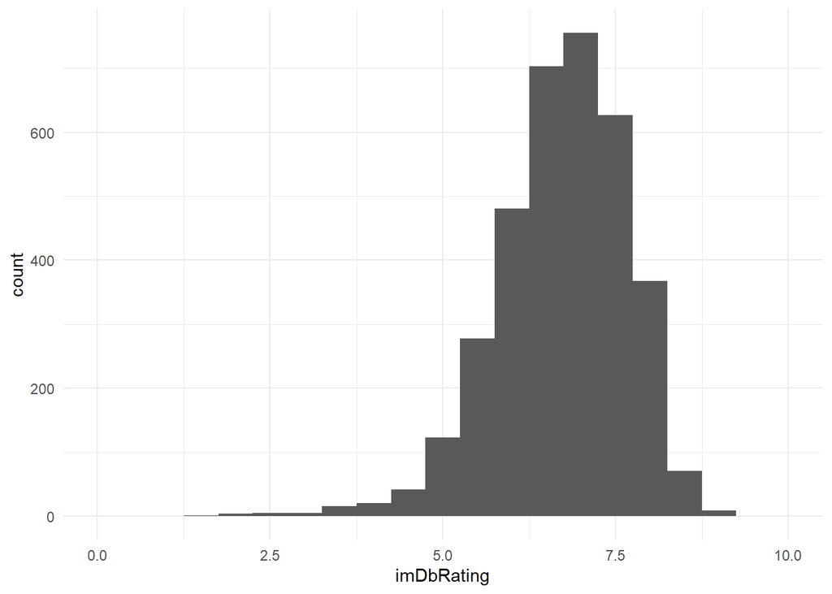

```r
movies %>%
  ggplot(aes(x = imDbRating)) +
  geom_histogram(binwidth = 0.5) +
  theme_minimal() +
  xlim(0, 10)
```

Referring back to the “random” movies remark, here we can clearly see that the IMDb scores follow a gaussian trend, which let’s us treat the data as a random sample.

## Specify the appropriate level of measurement for each feature.

```r
movies <- movies %>%
  mutate(
    action = as.factor(action),
    adventure = as.factor(adventure),
    animation = as.factor(animation),
    biography = as.factor(biography),
    comedy = as.factor(comedy),
    crime = as.factor(crime),
    drama = as.factor(drama),
    family = as.factor(family),
    fantasy = as.factor(fantasy),
    filmnoir = as.factor(filmnoir),
    history = as.factor(history),
    horror = as.factor(horror),
    music = as.factor(music),
    musical = as.factor(musical),
    mystery = as.factor(mystery),
    realitytv = as.factor(realitytv),
    romance = as.factor(romance),
    scifi = as.factor(scifi),
    sport = as.factor(sport),
    thriller = as.factor(thriller),
    war = as.factor(war),
    western = as.factor(western),
    top_director = as.factor(top_director),
    top_actor = as.factor(top_actor),

    PG13 = as.factor(PG13),
    R = as.factor(R),
    PG = as.factor(PG),
    Passed = as.factor(Passed),
    G = as.factor(G),
    TVMA = as.factor(TVMA),
    TV14 = as.factor(TV14),
    Approved = as.factor(Approved),
    TVPG = as.factor(TVPG),
    GP = as.factor(GP),
    NC17 = as.factor(NC17),
    twelve = as.factor(twelve),
    M_PG = as.factor(M_PG),
    M = as.factor(M)
  )
```

## Split the data into training data and test data.

```r
# remove the missing values
movies <- movies %>%
  drop_na()
# split data
movies <- movies[sample(nrow(movies)),]
train <- seq(1, nrow(movies) * 0.8)
test <- seq(max(train) + 1, nrow(movies))

movies_train <- movies[train,]
movies_test <- movies[test,]
```

## Predicting whether a movie is likely to be in the top 1000 of IMDB

The 7.6 rating will be considered as a threshold for us to designate a potential top 1000 movie, i.e., a variable will be created in the dataset that is concerned with whether a movie has an IMDB rating above 7.6.

**First, we create a feature providing us with information about whether the movie has a rating higher than 7.6.**

```r
movies_train <- movies_train %>%
  mutate(top1000 = as.factor(ifelse(imDbRating > 7.6, 1, 0)))

movies_test <- movies_test %>%
  mutate(top1000 = as.factor(ifelse(imDbRating > 7.6, 1, 0)))
```

**Second, the analysis can begin.**

In the statistical analysis section, four models will be fitted, they are the simplest model, the logistic regression model with 5-fold cross validation; classifiers such as: bagging, random forest, and boosting with 5-fold cross validation. Finally, the performance of all the mentioned models will be examined on a test dataset to identify the best predictive model.

*1. 5-fold cross-validation Logistic Regression*

```r
# specify the cross-validation method, and number of k-fold
train_control <- trainControl(method = "cv", number = 5)
```

```r
movies_train <- movies_train %>%
  select(-id,-title,-imDbRating,-director,-actors,-realitytv,-year)
```

```r
# fit the LR model on training dataset
lr_cv <- train(
  top1000 ~ .,
  data = movies_train,
  trControl = train_control,
  method = "glm",
  family = binomial()
)
summary(lr_cv)
```

```
##
## Call:
## NULL
##
## Deviance Residuals:
##     Min       1Q   Median       3Q      Max
## -2.2548  -0.3273  -0.1359  -0.0404   3.3235
##
## Coefficients:
##                         Estimate      Std. Error z value             Pr(>|z|)
## (Intercept)        -9.1402151508    0.9742864542  -9.381 < 0.0000000000000002
## imDbRatingVotes     0.0000065470    0.0000005813  11.263 < 0.0000000000000002
## metacriticRating    0.0910860765    0.0075759023  12.023 < 0.0000000000000002
## runtime             0.0176368077    0.0044575890   3.957           0.00007603
## action1            -0.4536996353    0.2809134809  -1.615             0.106292
## adventure1         -1.1191352380    0.2999582345  -3.731             0.000191
## animation1          1.0884514774    0.3411019059   3.191             0.001418
## biography1         -0.0375641747    0.2777243363  -0.135             0.892409
## comedy1            -0.7189297308    0.2690459314  -2.672             0.007537
## crime1             -0.0386860085    0.2734430639  -0.141             0.887493
## drama1              0.2518856338    0.2840011437   0.887             0.375123
## family1            -0.2525230899    0.3791191273  -0.666             0.505361
## fantasy1           -0.2394533449    0.3658134764  -0.655             0.512740
## filmnoir1           0.2282654860    0.7944606755   0.287             0.773866
## history1           -0.5022669164    0.3702840113  -1.356             0.174960
## horror1            -1.5273613484    0.4997231012  -3.056             0.002240
## music1              0.4040088913    0.3974510676   1.016             0.309391
## musical1           -0.7635624462    0.5884472431  -1.298             0.194429
## mystery1           -0.4363303360    0.3418821824  -1.276             0.201864
## romance1           -0.3042955919    0.3082932035  -0.987             0.323626
## scifi1             -1.4196103976    0.4312136764  -3.292             0.000994
## sport1             -1.4755878294    0.6577855643  -2.243             0.024880
## thriller1          -0.5785406332    0.3303814854  -1.751             0.079924
## war1                0.1033872057    0.4586706776   0.225             0.821663
## western1           -0.1127967033    0.5901335971  -0.191             0.848418
## PG131              -1.8905039765    0.4336140136  -4.360           0.00001301
## R1                 -1.8567040689    0.4044234530  -4.591           0.00000441
## PG1                -0.9528148563    0.4452875332  -2.140             0.032373
## Passed1             1.0486677270    0.6940124501   1.511             0.130783
## G1                 -1.6907772287    0.5594744397  -3.022             0.002510
```

[output cut: 48 more lines]

```
## twelve1
## M_PG1
## M1
## top_director1    **
## top_actor1
## ---
## Signif. codes:  0 '***' 0.001 '**' 0.01 '*' 0.05 '.' 0.1 ' ' 1
##
## (Dispersion parameter for binomial family taken to be 1)
##
##     Null deviance: 2081.7  on 2444  degrees of freedom
## Residual deviance: 1008.8  on 2404  degrees of freedom
## AIC: 1090.8
##
## Number of Fisher Scoring iterations: 14
```

Regarding content ratings, there are four content ratings that affect a movie’s chances of making the IMDB Top 1000: `PG-13`, `R`, `PG`, `G`. They all have a negative association with entry into the IMDB Top 1000, i.e., if a movie is listed as one of the above content ratings, the log-odds of entering the IMDB Top 1000 will decrease.

Notably, the `director` of the movie also serves as an influencing element. If a movie is directed by a top 250 director, the log-odds of entering the IMDB top 1000 will increase by 0.5.

```r
# create the confusion matrix on the training data
pred_lr <- predict(lr_cv, method = "response")

confusionMatrix(pred_lr, movies_train$top1000)
```

```
## Confusion Matrix and Statistics
##
##           Reference
## Prediction    0    1
##          0 2008  151
##          1   66  220
##
##                Accuracy : 0.9112
##                  95% CI : (0.8993, 0.9222)
##     No Information Rate : 0.8483
##     P-Value [Acc > NIR] : < 0.00000000000000022
##
##                   Kappa : 0.6194
##
##  Mcnemar's Test P-Value : 0.00000001182
##
##             Sensitivity : 0.9682
##             Specificity : 0.5930
##          Pos Pred Value : 0.9301
##          Neg Pred Value : 0.7692
##              Prevalence : 0.8483
##          Detection Rate : 0.8213
##    Detection Prevalence : 0.8830
##       Balanced Accuracy : 0.7806
##
##        'Positive' Class : 0
##
```

We built a confusion matrix for the 5-fold cross-validated logistic regression model on the training data. It can be seen that the accuracy of this model is 0.91, which is not bad, especially compared to the baseline accuracy, which is 0.85.

```r
# check the results on validation dataset
lr_cv
```

```
## Generalized Linear Model
##
## 2445 samples
##   40 predictor
##    2 classes: '0', '1'
##
## No pre-processing
## Resampling: Cross-Validated (5 fold)
## Summary of sample sizes: 1956, 1955, 1956, 1957, 1956
## Resampling results:
##
##   Accuracy   Kappa
##   0.8997962  0.570393
```

Furthermore, It can be seen that the accuracy of the 5-fold cross-validation logistic regression model on the validation datasets is 0.9.

*2. Bagging*

```r
# fit the bagging model on training dataset
bag_cv <- train(
  top1000 ~ .,
  data = movies_train,
  trControl = train_control,
  method = "treebag",
  importance = T
)
```

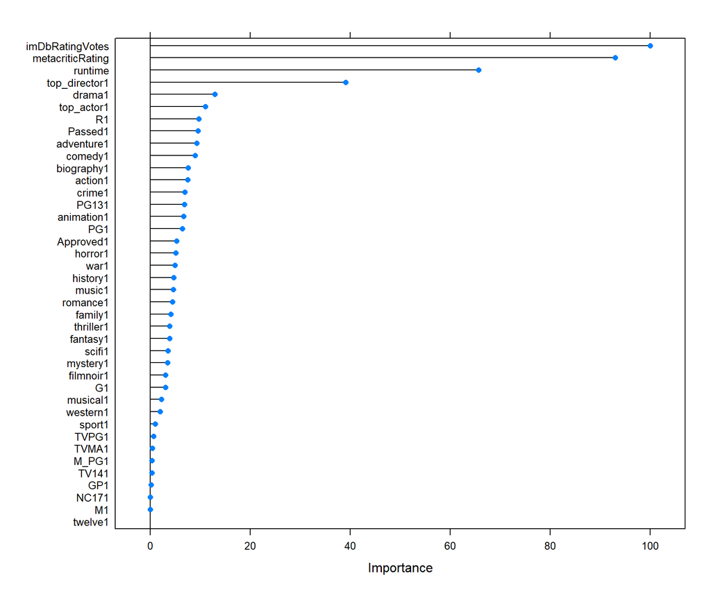

```r
# Check the feature importance plot
bag_cv %>%
  varImp %>%
  plot
```

The variable importance plot indicates that the four features with the highest importance in the bagging model are the total number of votes (`imDbRatingVotes`), the average rating of critics (`metacriticRating`), the running time of the movie (`runtime`), and a movie’s director being a top 250 director (`top_director`) or not. The remaining features are relatively less important than the above four.

```r
# create confusion matrix on training data
pred_bag <- predict(bag_cv, type = "raw")
confusionMatrix(pred_bag, movies_train$top1000)
```

```
## Confusion Matrix and Statistics
##
##           Reference
## Prediction    0    1
##          0 2074    4
##          1    0  367
##
##                Accuracy : 0.9984
##                  95% CI : (0.9958, 0.9996)
##     No Information Rate : 0.8483
##     P-Value [Acc > NIR] : <0.0000000000000002
##
##                   Kappa : 0.9936
##
##  Mcnemar's Test P-Value : 0.1336
##
##             Sensitivity : 1.0000
##             Specificity : 0.9892
##          Pos Pred Value : 0.9981
##          Neg Pred Value : 1.0000
##              Prevalence : 0.8483
##          Detection Rate : 0.8483
##    Detection Prevalence : 0.8499
##       Balanced Accuracy : 0.9946
##
##        'Positive' Class : 0
##
```

The confusion matrix of the bagging model on the training data shows almost perfect results with accuracy, sensitivity, specificity, PPV and NPV close to 1, again much higher than baseline accuracy. However, it is still not certain if it is a decent model as we do not know whether it is over-fitted or not.

```r
# check the results on internal validation dataset
bag_cv
```

```
## Bagged CART
##
## 2445 samples
##   40 predictor
##    2 classes: '0', '1'
##
## No pre-processing
## Resampling: Cross-Validated (5 fold)
## Summary of sample sizes: 1957, 1956, 1955, 1956, 1956
## Resampling results:
##
##   Accuracy  Kappa
##   0.894894  0.5564865
```

The most characteristic of the bagging method is that it uses bootstrap aggregation to obtain many training datasets by sampling multiple times from the sample, fitting a tree to each training dataset, and using majority vote for classification or simple average for regression. The out of bag data can be served as the internal validation datasets. Hence, we can observe that the accuracy of the internal validation dataset shown here is 0.89.

*3. Random Forest*

```r
# fit the bagging model on training dataset
rf_cv <- train(
  top1000 ~ .,
  data = movies_train,
  trControl = train_control,
  method = "rf",
  importance = T
)
```

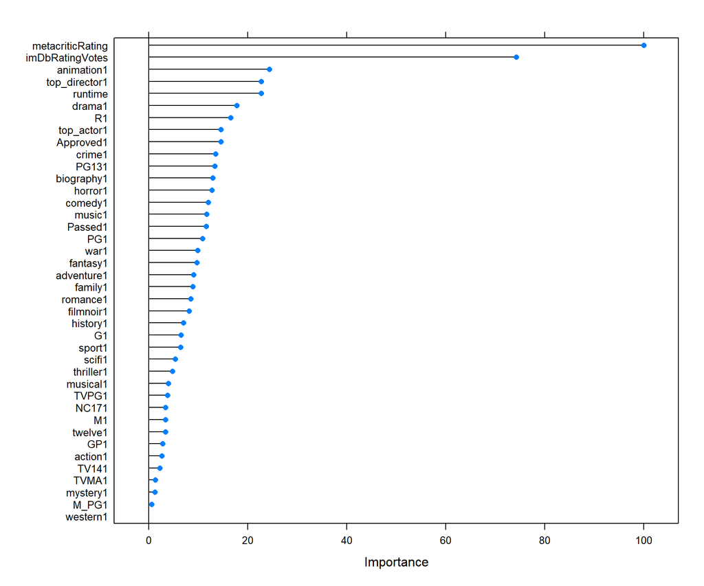

```r
# Check the feature importance plot
rf_cv %>%
  varImp %>%
  plot
```

The random forest model reveals a different variable importance plot than the bagging model. The reason for this is that bagging has a high correlation issue between the trees. To overcome this problem, the random forest places a restriction on each split of the tree by randomly drawing features at any split with only those features that are drawn being considered.

Here, the random forest model suggests that the critics’ rating (`metacriticRating`) is the most important feature, followed by the total number of votes (`imDbRatingVotes`), then by whether the movie is animation (`animation`) or not, and whether the movie’s director is a top 250 director (`top_director`), then the movie’s running time (`runtime`). The features listed behind the total number of votes (`imDbRatingVotes`) are, however, relatively much less important in the variable importance plot than for ur previous model.

```r
# create confusion matrix on the training data
pred_rf <- predict(rf_cv, type = "raw")
confusionMatrix(pred_rf, movies_train$top1000)
```

```
## Confusion Matrix and Statistics
##
##           Reference
## Prediction    0    1
##          0 2074    0
##          1    0  371
##
##                Accuracy : 1
##                  95% CI : (0.9985, 1)
##     No Information Rate : 0.8483
##     P-Value [Acc > NIR] : < 0.00000000000000022
##
##                   Kappa : 1
##
##  Mcnemar's Test P-Value : NA
##
##             Sensitivity : 1.0000
##             Specificity : 1.0000
##          Pos Pred Value : 1.0000
##          Neg Pred Value : 1.0000
##              Prevalence : 0.8483
##          Detection Rate : 0.8483
##    Detection Prevalence : 0.8483
##       Balanced Accuracy : 1.0000
##
##        'Positive' Class : 0
##
```

Similar to the output of the bagging model, the confusion matrix of the random forest model on the training data displays nearly perfect results with accuracy, sensitivity, specificity, PPV, and NPV equal to 1. Nevertheless, it is still uncertain whether it is a decent model, as we do not know either it is over-fitting or not.

```r
# check the results on internal validation dataset
rf_cv
```

```
## Random Forest
##
## 2445 samples
##   40 predictor
##    2 classes: '0', '1'
##
## No pre-processing
## Resampling: Cross-Validated (5 fold)
## Summary of sample sizes: 1955, 1956, 1956, 1957, 1956
## Resampling results across tuning parameters:
##
##   mtry  Accuracy   Kappa
##    2    0.8711629  0.2360772
##   21    0.8997962  0.5601072
##   40    0.9002010  0.5647171
##
## Accuracy was used to select the optimal model using the largest value.
## The final value used for the model was mtry = 40.
```

Due to the similarity with the bagging method, the random forest has the internal validation data set from which the accuracy can be tested. Here, we can see that the random forest model has the highest accuracy of 0.9 as 40 features are sampled in each split.

*4. 5-fold cross-validation Boosting*

```r
# fit the bagging model on training dataset
boost_cv <- train(
  top1000 ~ .,
  data = movies_train,
  trControl = train_control,
  method = "gbm",
  verbose = F,
)
```

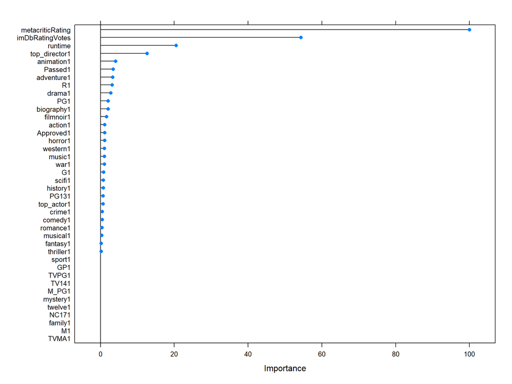

```r
# Check the feature importance plot
boost_cv %>%
  varImp %>%
  plot
```

The order of importance of the features is similar to that of the random forest model, as can be seen from the variable importance plot of the boosting model. Critics’ rating (`metacriticRating`) is the most important feature, next is the total number of votes (`imDbRatingVotes`), followed by the running time of the movie (`runtime`), and whether the director of the movie is a top 250 director (`top_director`). Compared to the random forest model, however, the features listed after the fourth variable in the boosted model contribute little to the model.

```r
# create confusion matrix on the training data
pred_boost <- predict(boost_cv, type = "raw")
confusionMatrix(pred_boost, movies_train$top1000)
```

```
## Confusion Matrix and Statistics
##
##           Reference
## Prediction    0    1
##          0 2024  133
##          1   50  238
##
##                Accuracy : 0.9252
##                  95% CI : (0.914, 0.9353)
##     No Information Rate : 0.8483
##     P-Value [Acc > NIR] : < 0.00000000000000022
##
##                   Kappa : 0.6798
##
##  Mcnemar's Test P-Value : 0.000000001348
##
##             Sensitivity : 0.9759
##             Specificity : 0.6415
##          Pos Pred Value : 0.9383
##          Neg Pred Value : 0.8264
##              Prevalence : 0.8483
##          Detection Rate : 0.8278
##    Detection Prevalence : 0.8822
##       Balanced Accuracy : 0.8087
##
##        'Positive' Class : 0
##
```

The confusion matrix of the boosting model on the training data has an accuracy of 0.93, a sensitivity of 0.98, a slightly lower specificity of 0.64, a PPV of 0.94, and an NPV of 0.83.

```r
# check the results on the validation dataset
boost_cv
```

```
## Stochastic Gradient Boosting
##
## 2445 samples
##   40 predictor
##    2 classes: '0', '1'
##
## No pre-processing
## Resampling: Cross-Validated (5 fold)
## Summary of sample sizes: 1956, 1956, 1956, 1956, 1956
## Resampling results across tuning parameters:
##
##   interaction.depth  n.trees  Accuracy   Kappa
##   1                   50      0.8977505  0.5236095
##   1                  100      0.8973415  0.5390229
##   1                  150      0.8993865  0.5494379
##   2                   50      0.8997955  0.5494192
##   2                  100      0.9010225  0.5664959
##   2                  150      0.8993865  0.5678437
##   3                   50      0.9014315  0.5612735
##   3                  100      0.9006135  0.5643520
##   3                  150      0.9026585  0.5733405
##
## Tuning parameter 'shrinkage' was held constant at a value of 0.1
##
## Tuning parameter 'n.minobsinnode' was held constant at a value of 10
## Accuracy was used to select the optimal model using the largest value.
## The final values used for the model were n.trees = 150, interaction.depth =
##  3, shrinkage = 0.1 and n.minobsinnode = 10.
```

Based on the accuracy of the 5-fold cross-validation boosting model on the validation datasets, the best accuracy of the boosting model is 0.9 for three splits on a tree with 150 trees.

**Third, let’s test on the test data and determine which model has the best performance.**

```r
# fit all the models on the test data
lr_test <- predict(lr_cv, newdata = movies_test)
bag_test <- predict(bag_cv, newdata = movies_test)
rf_test  <- predict(rf_cv, newdata = movies_test)
boost_test <- predict(boost_cv, newdata = movies_test)
```

```r
# show the confusion matrix and related info of each model
list(
  Five_fold_CV_LR = lr_test,
  Bagging = bag_test,
  Random_Forest = rf_test,
  Five_fold_CV_Boosting = boost_test
) %>%
  map( ~ confusionMatrix(.x, movies_test$top1000))
```

```
## $Five_fold_CV_LR
## Confusion Matrix and Statistics
##
##           Reference
## Prediction   0   1
##          0 512  39
##          1  16  45
##
##                Accuracy : 0.9101
##                  95% CI : (0.8846, 0.9316)
##     No Information Rate : 0.8627
##     P-Value [Acc > NIR] : 0.0002147
##
##                   Kappa : 0.5712
##
##  Mcnemar's Test P-Value : 0.0030123
##
##             Sensitivity : 0.9697
##             Specificity : 0.5357
##          Pos Pred Value : 0.9292
##          Neg Pred Value : 0.7377
##              Prevalence : 0.8627
##          Detection Rate : 0.8366
##    Detection Prevalence : 0.9003
##       Balanced Accuracy : 0.7527
##
##        'Positive' Class : 0
##
##
## $Bagging
## Confusion Matrix and Statistics
##
##           Reference
## Prediction   0   1
##          0 510  39
##          1  18  45
##
##                Accuracy : 0.9069
##                  95% CI : (0.881, 0.9287)
##     No Information Rate : 0.8627
```

[output cut: 60 more lines]

```
##                   Kappa : 0.6196
##
##  Mcnemar's Test P-Value : 0.04995
##
##             Sensitivity : 0.9659
##             Specificity : 0.6071
##          Pos Pred Value : 0.9392
##          Neg Pred Value : 0.7391
##              Prevalence : 0.8627
##          Detection Rate : 0.8333
##    Detection Prevalence : 0.8873
##       Balanced Accuracy : 0.7865
##
##        'Positive' Class : 0
##
```

All four models (i.e., the 5-fold cross-validation logistic regression model, the bagging model, the random forest model, and the 5-fold cross-validation boosting model) were fitted to the test dataset we partitioned at the beginning to test and compare the performance of each model.

First, we evaluated the accuracy of each model - the boosting model had the highest accuracy at 0.92, followed by the logistic regression model at 0.91, and the bagging model and random forest model had the lowest accuracy at 0.907.

Second, as we are most interested in what is the probability that a movie is actually in the IMDB top 1000 if it is identified as likely to be in the IMDB top 1000, and what is the probability that a movie is truly not in the IMDB top 1000 if it is identified as unlikely to be in the top 1000, thus, the PPV and NPV of the models are of interest to us for comparison. The bagging model performed the worst on PPV and NPV, the random forest and logistic regression models were nearly the same, the boosting model had the best overall performance on PPV and NPV with a PPV of 0.94 and an NPV of 0.74.

To conclude, among the four models we compared, the boosting model is the most ideal model so that it is served as our final model.

## Which movies will be worth watching this year, then?

There is a [comprehensive list by Rotten Tomatoes about the most antecipated movies of the year](https://editorial.rottentomatoes.com/article/most-anticipated-movies-of-2022/) and we think we should try to be helpful and let you know which ones you should be watching! (using our best model - the boosting one) As they are coming out in the future, we are going to impute the `imDbRatingVotes` variable.

Let us, then, create a dataset with the movies starting from November that we have information on:

```r
title <-
  c(
    "Enola Holmes 2",
    "Black Panther: Wakanda Forever",
    "The Menu",
    "Devotion",
    "The Fabelmans",
    "Glass Onion: A Knives Out Mystery",
    "Pinocchio",
    "The Whale",
    "Avatar: The Way of Water",
    "I Wanna Dance With Somebody",
    "Puss in Boots: The Last Wish",
    "The Pale Blue Eye",
    "Babylon"
  )
imDbRatingVotes <-
  c(NA, NA, NA, NA, NA, NA, NA, NA, NA, NA, NA, NA, NA)
metacriticRating <-
  c(64, 67, 74, 60, 86, 81, 89, 65, NA, NA, NA, NA, NA)
runtime <-
  c(129, 161, 106, 138, 151, 139, 117, 117, 190, NA, NA, 128, 188)
year <-
  c(2022,
    2022,
    2022,
    2022,
    2022,
    2022,
    2022,
    2022,
    2022,
    2022,
    2022,
    2022,
    2022)
director <-
  c(
    "Harry Bradbeer",
    "Ryan Coogler",
    "Mark Mylod",
    "J.D. Dillard",
    "Steven Spielberg",
    "Rian Johnson",
    "Guillermo del Toro",
    "Darren Aronofsky",
    "James Cameron",
    "Kasi Lemmons",
    "Joel Crawford",
    "Scott Cooper",
    "Damien Chazelle"
  )
actors <-
  c(
    "Millie Bobby Brown, Henry Cavill, David Thewlis",
    "Letitia Wright, Lupita Nyong'o, Danai Gurira",
    "Anya Taylor-Joy, Ralph Fiennes, Nicholas Hoult",
    "Glen Powell, Jonathan Majors, Serinda Swan",
    "Michelle Williams, Gabriel LaBelle, Paul Dano",
    "Daniel Craig, Edward Norton, Kate Hudson",
    "Gregory Mann, Ewan McGregor, Ron Perlman",
    "Brendan Fraser, Sadie Sink, Ty Simpkins",
    "Zoe Saldana, Sigourney Weaver, Sam Worthington",
    "Stanley Tucci, Naomi Ackie, Tamara Tunie",
    "Antonio Banderas, Salma Hayek, Harvey Guillén",
    "Christian Bale, Gillian Anderson, Harry Melling",
    "Brad Pitt, Margot Robbie, Jean Smart"
  )
genres <-
  c(
    "Action, Adventure, Crime",
    "Action, Adventure, Drama",
    "Comedy, Horror, Thriller",
    "Action, Drama, War",
    "Drama",
    "Comedy, Crime, Drama",
    "Animation, Drama, Family",
    "Drama",
    "Action, Adventure, Fantasy",
    "Biography, Drama, Music",
    "Animation, Adventure, Comedy",
    "Crime, Horror, Mystery",
    "Comedy, Drama, Hystory"
  )
contentRating <-
  c("PG-13",
    "M/12",
    "R",
    "PG-13",
    "PG-13",
    "PG-13",
    "PG",
    "R",
    NA,
    NA,
    "PG",
    "R",
    NA)
```

```r
upcoming <- tibble(
  title = title,
  imDbRatingVotes = as.numeric(imDbRatingVotes),
  metacriticRating = metacriticRating,
  runtime = runtime,
  year = year,
  director = director,
  actors = actors,
  genres = genres,
  contentRating = as.factor(contentRating)
)
```

```r
upcoming <-
  upcoming %>%
  mutate(
    action = ifelse(grepl("Action", genres, fixed = TRUE), 1, 0),
    adventure = ifelse(grepl("Adventure", genres, fixed = TRUE), 1, 0),
    animation = ifelse(grepl("Animation", genres, fixed = TRUE), 1, 0),
    biography = ifelse(grepl("Biography", genres, fixed = TRUE), 1, 0),
    comedy = ifelse(grepl("Comedy", genres, fixed = TRUE), 1, 0),
    crime = ifelse(grepl("Crime", genres, fixed = TRUE), 1, 0),
    drama = ifelse(grepl("Drama", genres, fixed = TRUE), 1, 0),
    family = ifelse(grepl("Family", genres, fixed = TRUE), 1, 0),
    fantasy = ifelse(grepl("Fantasy", genres, fixed = TRUE), 1, 0),
    filmnoir = ifelse(grepl("Film-Noir", genres, fixed = TRUE), 1, 0),
    history = ifelse(grepl("History", genres, fixed = TRUE), 1, 0),
    horror = ifelse(grepl("Horror", genres, fixed = TRUE), 1, 0),
    music = ifelse(grepl("Music", genres, fixed = TRUE), 1, 0),
    musical = ifelse(grepl("Musical", genres, fixed = TRUE), 1, 0),
    mystery = ifelse(grepl("Mystery", genres, fixed = TRUE), 1, 0),
    realitytv = ifelse(grepl("Reality-TV", genres, fixed = TRUE), 1, 0),
    romance = ifelse(grepl("Romance", genres, fixed = TRUE), 1, 0),
    scifi = ifelse(grepl("Sci-Fi", genres, fixed = TRUE), 1, 0),
    sport = ifelse(grepl("Sport", genres, fixed = TRUE), 1, 0),
    thriller = ifelse(grepl("Thriller", genres, fixed = TRUE), 1, 0),
    war = ifelse(grepl("War", genres, fixed = TRUE), 1, 0),
    western = ifelse(grepl("Western", genres, fixed = TRUE), 1, 0),
  ) %>%
  select(-genres)
```

```r
upcoming <-
  upcoming %>%
  filter(contentRating != "Not Rated", contentRating != "Unrated") %>%
  mutate(
    PG13 = ifelse(contentRating == "PG-13", 1, 0),
    R = ifelse(contentRating == "R", 1, 0),
    PG = ifelse(contentRating == "PG", 1, 0),
    Passed = ifelse(contentRating == "Passed", 1, 0),
    G = ifelse(contentRating == "G", 1, 0),
    TVMA = ifelse(contentRating == "TV-MA", 1, 0),
    TV14 = ifelse(contentRating == "TV-14", 1, 0),
    Approved = ifelse(contentRating == "Approved", 1, 0),
    TVPG = ifelse(contentRating == "TV-PG", 1, 0),
    GP = ifelse(contentRating == "GP", 1, 0),
    NC17 = ifelse(contentRating == "NC-17", 1, 0),
    twelve = ifelse(contentRating == "12", 1, 0),
    M_PG = ifelse(contentRating == "M/PG", 1, 0),
    M = ifelse(contentRating == "M", 1, 0)
  ) %>%
  select(-contentRating)
```

```r
upcoming <-
  upcoming %>%
  mutate(top_director = ifelse(director %in% top_directors, 1, 0))
```

```r
upcoming <-
  upcoming %>%
  mutate(actor1 = sub(", .*", "", upcoming$actors)) %>%
  mutate(actors = substring(actors, first = nchar(actor1) + 3))
upcoming <-
  upcoming %>%
  mutate(actor2 = sub(", .*", "", upcoming$actors)) %>%
  mutate(actor3 = substring(actors, first = nchar(actor2) + 3)) %>%
  select(-actors)
```

```r
upcoming <-
  upcoming %>%
  mutate(top_actor = ifelse(
    actor1 %in% top_actors |
      actor2 %in% top_actors |
      actor3 %in% top_actors,
    1,
    0
  ))
upcoming <-
  upcoming %>%
  select(-actor1, -actor2, -actor3)
```

```r
upcoming <- upcoming %>%
  mutate(
    action = as.factor(action),
    adventure = as.factor(adventure),
    animation = as.factor(animation),
    biography = as.factor(biography),
    comedy = as.factor(comedy),
    crime = as.factor(crime),
    drama = as.factor(drama),
    family = as.factor(family),
    fantasy = as.factor(fantasy),
    filmnoir = as.factor(filmnoir),
    history = as.factor(history),
    horror = as.factor(horror),
    music = as.factor(music),
    musical = as.factor(musical),
    mystery = as.factor(mystery),
    realitytv = as.factor(realitytv),
    romance = as.factor(romance),
    scifi = as.factor(scifi),
    sport = as.factor(sport),
    thriller = as.factor(thriller),
    war = as.factor(war),
    western = as.factor(western),
    top_director = as.factor(top_director),
    top_actor = as.factor(top_actor),

    PG13 = as.factor(PG13),
    R = as.factor(R),
    PG = as.factor(PG),
    Passed = as.factor(Passed),
    G = as.factor(G),
    TVMA = as.factor(TVMA),
    TV14 = as.factor(TV14),
    Approved = as.factor(Approved),
    TVPG = as.factor(TVPG),
    GP = as.factor(GP),
    NC17 = as.factor(NC17),
    twelve = as.factor(twelve),
    M_PG = as.factor(M_PG),
    M = as.factor(M)
  )
```

**Start Imputation**

Here we started our imputation work. In order to have a plausible imputation result, we randomly sampled 30 old movies from the `movies` dataset combined with upcoming movies.

```r
old <- movies[sample(nrow(movies), 30),] %>%
  select(-id,-imDbRating,-actors)

upcoming <- rbind(old, upcoming)
```

Let us plot the pattern of missing values.

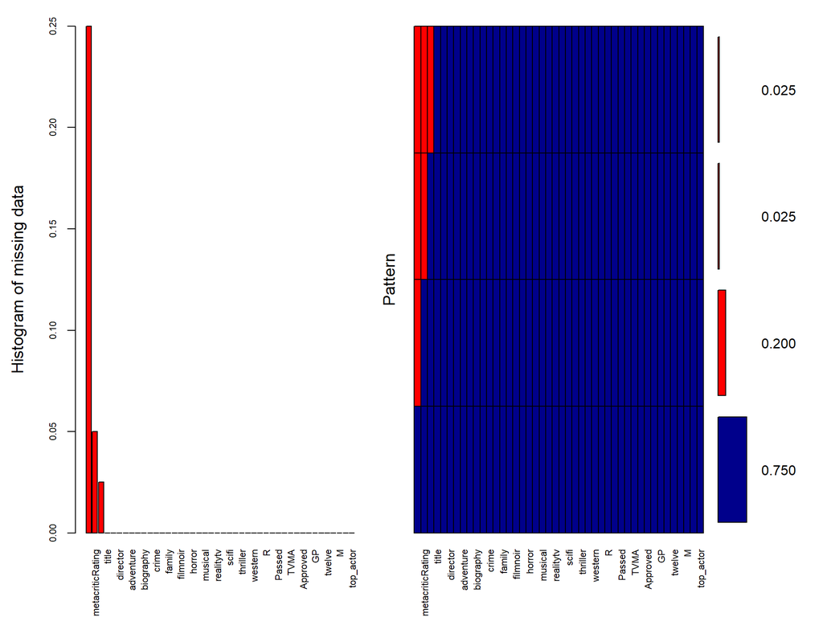

```
##
##  Variables sorted by number of missings:
##          Variable Count
##   imDbRatingVotes 0.250
##  metacriticRating 0.050
##           runtime 0.025
##             title 0.000
##              year 0.000
##          director 0.000
##            action 0.000
##         adventure 0.000
##         animation 0.000
##         biography 0.000
##            comedy 0.000
##             crime 0.000
##             drama 0.000
##            family 0.000
##           fantasy 0.000
##          filmnoir 0.000
##           history 0.000
##            horror 0.000
##             music 0.000
##           musical 0.000
##           mystery 0.000
##         realitytv 0.000
##           romance 0.000
##             scifi 0.000
##             sport 0.000
##          thriller 0.000
##               war 0.000
##           western 0.000
##              PG13 0.000
##                 R 0.000
##                PG 0.000
##            Passed 0.000
##                 G 0.000
##              TVMA 0.000
##              TV14 0.000
##          Approved 0.000
##              TVPG 0.000
##                GP 0.000
##              NC17 0.000
##            twelve 0.000
##              M_PG 0.000
##                 M 0.000
##      top_director 0.000
##         top_actor 0.000
```

```r
miss_plot <- aggr(upcoming, col=c('darkblue','red'), numbers=T, sortVars=T, labels=names(data), cex.axis=.7, gap=3, ylab=c("Histogram of missing data","Pattern"))
```

The graph reveals that 75% of the data has no missing information, 25% of the data is missing the number of votes.

*Use classification and regression trees method for imputation*

```r
imp <- mice(upcoming,m=5,maxit=50,meth='cart',seed=999)
summary(imp)
```

In the imputation section, we adopted a classification and regression tree method as there are some imbalances in our data (i.e., Genre) that turn out to be dummy variables, some of which may be linear combinations of others. The predictive mean matching involves linear regression, that may lead to some errors, so that in our case, cart is a more suitable method.

*Check the results of our imputation*

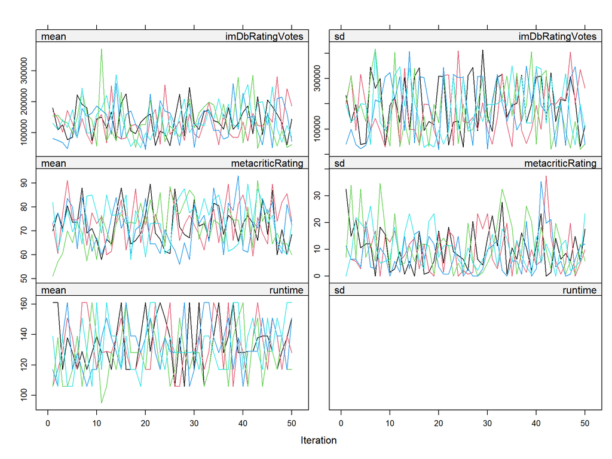

```r
plot(imp)
```

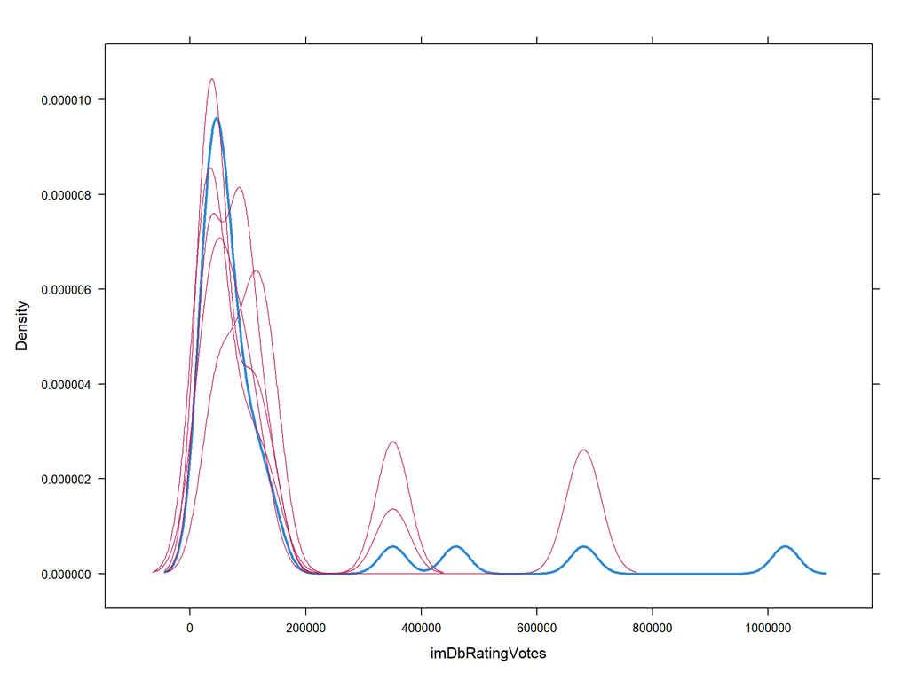

```r
densityplot(imp)
```

In our case, the convergence is satisfied from most of the spaghetti plots, also the density plot appears to be acceptable with most of the lines following the shape of the observed data (blue).

*We therefore obtain our imputed data*

```r
upcoming_imp <- complete(imp,1)
```

**Start our prediction**

```r
upcoming_pred <- predict(boost_cv, newdata = upcoming_imp)

upcoming_imp <-
  upcoming_imp %>%
  mutate(pred = upcoming_pred)

upcoming_imp %>%
  tail(10) %>%
  select(title, pred)
```

```
##                                title pred
## 31                    Enola Holmes 2    0
## 32    Black Panther: Wakanda Forever    0
## 33                          The Menu    0
## 34                          Devotion    0
## 35                     The Fabelmans    1
## 36 Glass Onion: A Knives Out Mystery    0
## 37                         Pinocchio    1
## 38                         The Whale    0
## 39      Puss in Boots: The Last Wish    0
## 40                 The Pale Blue Eye    0
```

According to our model, only two of the “Most Anticipated Movies for 2022” is actually worth watching, `The Fabelmans` and `Pinocchio`. This means we predict thess films will have an IMDb rating of over 7.6 and is likely to make it into IMDB’s top 1000.